# Exploratory Data Analysis(EDA) - S&P 500 Returns

This R notebook conducts an observational study on a sample of S&P 500 returns from 1/1/2000 to 12/31/2025. The general purpose of this notebook is to gain familiarity with the syntax of R and showcase EDA relating to financial time-series data. I also provide commentary on the observations made throughout the notebook. The HTML was rendered from the corresponding R notebook script.

```r
# Load libraries
library(quantmod)
library(moments)

# Download data
ohlcv = getSymbols("SPY", src="yahoo", from="2000-01-01", to="2025-12-31", auto.assign=FALSE)

# Compute returns
r_t  = dailyReturn(Cl(ohlcv), type="arithmetic")
mr_t = monthlyReturn(Cl(ohlcv), type="arithmetic")

r_t  = na.omit(r_t)
mr_t = na.omit(mr_t)
```

### Plots

This section explores various types of plots for return and price.

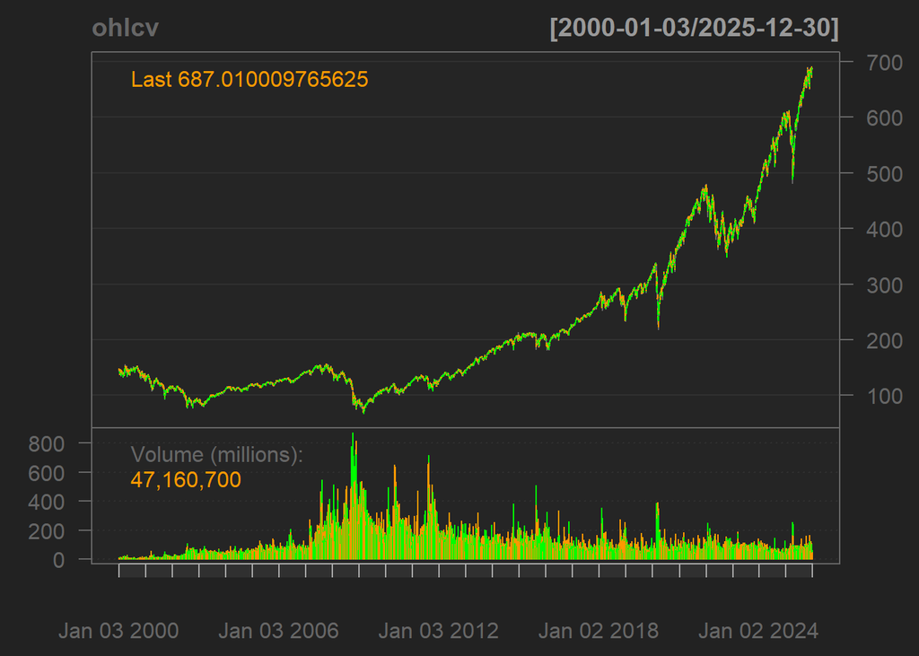

```r
# Create a daily candlestick chart
chartSeries(ohlcv)
```

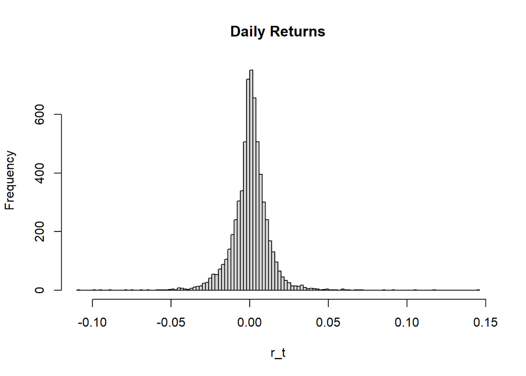

```r
hist(
  r_t,
  main="Daily Returns",
  xlim=c(min(r_t), max(r_t)),
  breaks=100
)
```

Visually inspecting the daily return distribution, it appears to follow a normal distribution, with fatter tails. Below is the Q-Q plot to further inspect tail behavior.

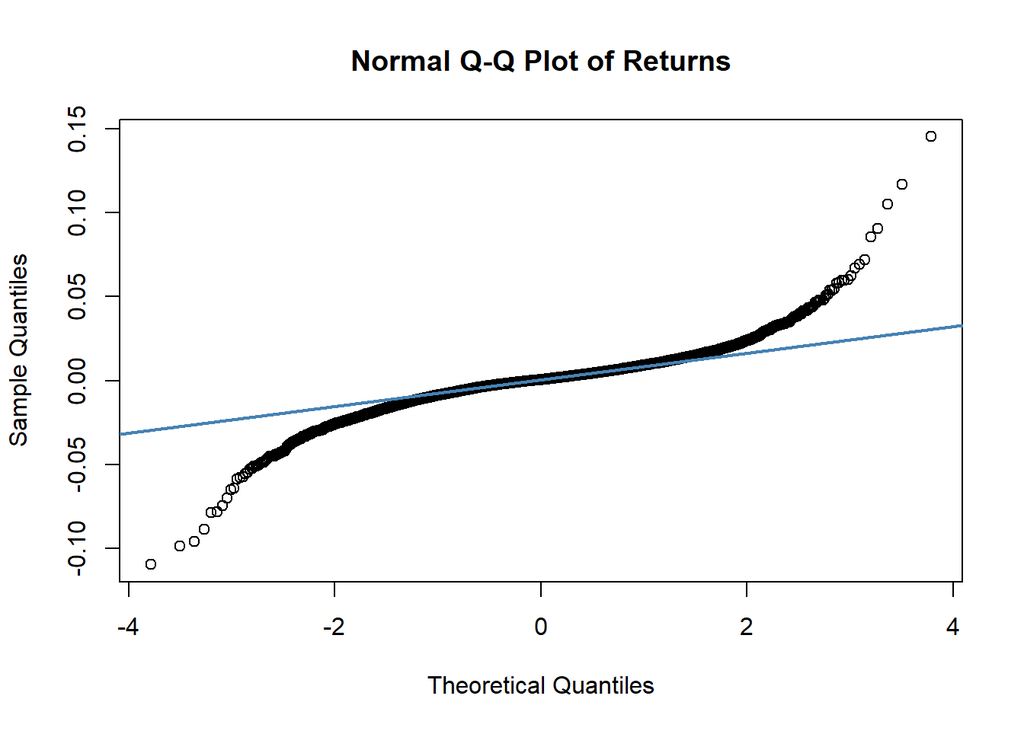

```r
# Normal Q-Q plot
qqnorm(r_t, main="Normal Q-Q Plot of Returns")
qqline(r_t, col="steelblue", lwd=2)
```

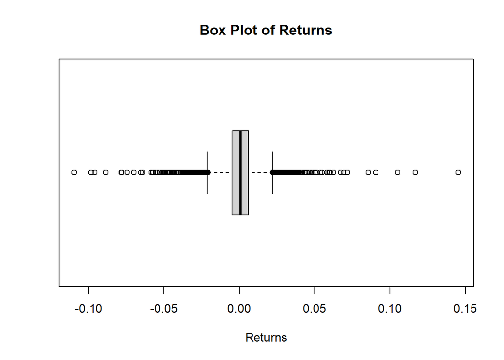

```r
# Box plot of daily returns
boxplot(
  r_t,
  main="Box Plot of Returns",
  xlab="Returns",
  horizontal=TRUE
)
```

From the box-plot, we can see there are many return outliers, further validating the fat tail behavior of the daily return distribution.

### Numerical Summaries

This section computes numerical statistics for return data.

```r
# Compute the summary statistics
var_95 = quantile(r_t, 0.05)

statistics = c(
  mean = mean(r_t),
  meadian = median(r_t),
  min = min(r_t),
  max = max(r_t),
  iqr = IQR(r_t),
  sd   = sd(r_t),
  skew = skewness(r_t),
  kurt = kurtosis(r_t),
  VaR_95 = var_95,
  ES_95 = mean(r_t[r_t <= var_95])
)
statistics_df = data.frame(
  Statistic=names(statistics),
  Value=round(as.numeric(statistics), 6)
)

print(statistics_df, row.names=FALSE)
```

```
##           Statistic     Value
##                mean  0.000312
##             meadian  0.000631
##                 min -0.109424
##                 max  0.145198
##                 iqr  0.010759
##                  sd  0.012239
##  skew.daily.returns  0.043367
##  kurt.daily.returns 14.945455
##           VaR_95.5% -0.019073
##               ES_95 -0.029342
```

The summary statistics give us numerical insights into the sample daily return distribution of the S&P 500.

The mean daily return was ~0.03% and the median daily return was ~0.06%. This suggests that, on average, the sample had a positive daily return.

The maximum one day return in the sample was ~14.5% and the minimum one day return in the sample was ~-10.9%. There are large daily returns in the sample. The next section explores the frequency of large returns.

The sample return distribution has a slight positive skew. The high kurtosis validates our observations in the plotting section; the return distribution has fat tails.

Based on the historical sample, the estimated probability of a daily return below −1.91% is 5%.

Based on the historical sample, the average return of the smallest 5% of returns is -2.93%.

```r
# Frequency table of positive and negative returns
BOUND = 0.025

frequency_table = rbind(
  data.frame(
    Type="Pos. R_t",
    Count=sum(r_t > 0),
    Probability=mean(r_t > 0)
  ),
  data.frame(
    Type="Neg. R_t",
    Count=sum(r_t < 0),
    Probability=mean(r_t < 0)
  ),
  data.frame(
    Type="Large Pos. (> BOUND)",
    Count=sum(r_t > BOUND),
    Probability=mean(r_t > BOUND)
  ),
  data.frame(
    Type="Large Neg. (< -BOUND)",
    Count=sum(r_t < -BOUND),
    Probability=mean(r_t < -BOUND)
  )
)

print(frequency_table)
```

```
##                    Type Count Probability
## 1              Pos. R_t  3536  0.54083818
## 2              Neg. R_t  2980  0.45579688
## 3  Large Pos. (> BOUND)   131  0.02003671
## 4 Large Neg. (< -BOUND)   162  0.02477822
```

We can see that ~54% of the daily returns were positive and ~46% of the daily returns were negative in the sample. We can also observe that ~2% of the daily returns were greater than the bound and ~2.5% of the daily returns were lower than the bound.

```r
# Mean day of the week return
dow = weekdays(index(r_t))

aggregate(r_t, by=list(dow), mean)
```

```
##
## Friday    -0.0001947930
## Monday     0.0003603448
## Thursday   0.0002666920
## Tuesday    0.0006587070
## Wednesday  0.0004631526
```

```r
month = months(index(mr_t))

aggregate(mr_t, by=list(month), mean)
```

```
##
## April      0.016761798
## August     0.003570860
## December   0.001688576
## February  -0.002420312
## January    0.001154267
## July       0.016598160
## June      -0.003852184
## March      0.007526238
## May        0.008823490
## November   0.024162936
## October    0.013733313
## September -0.016250244
```

The section above aggregates the mean returns by the day of the week and month.

February, June, and September had negative mean returns, while the rest of the months had positive mean returns. November had the largest mean return (2.42%).